# 실험계획법

# Chapter 2 Some Basic Statistical Concept

## Graphical View of the Data

```r
dat_2_1 <- read.table(file='./data/example_2_1.txt', sep='\t', header = T)
dat_2_1
```

```
      y1    y2
1  16.85 16.62
2  16.40 16.75
3  17.21 17.37
4  16.35 17.12
5  16.52 16.98
6  17.04 16.87
7  16.96 17.34
8  17.15 17.02
9  16.59 17.08
10 16.57 17.27
```

### 1) Dot Diagram

**stripchart**

- list를 이용해 두 값을 비교
- pch: value 모양 지정
- xaxt=‘n’: x축을 출력 안함

**axis**

- lwd: x축의 두께
- pos: x축의 위치

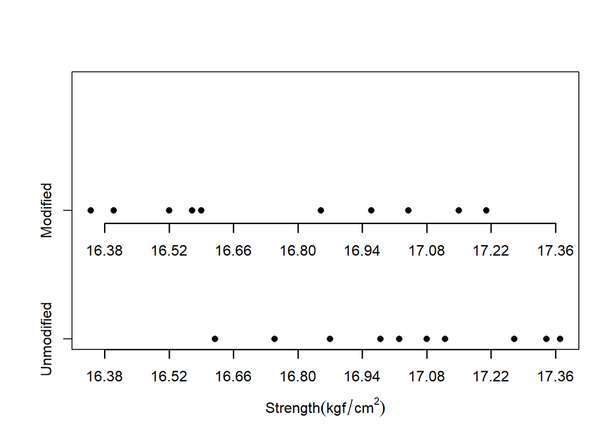

```r
stripchart(list('Unmodified'=dat_2_1$y2, 'Modified'=dat_2_1$y1),
            ylim=c(1,3), pch = 16, xaxt='n', xlab=expression(Strength(kgf/cm^2)))
axis(1, at=seq(16.38, 17.36,by=0.14), lwd=1.5)
axis(1, at=seq(16.38, 17.36, by=0.14), lwd=1.5, pos=1.9)
```

### 2) Box plots

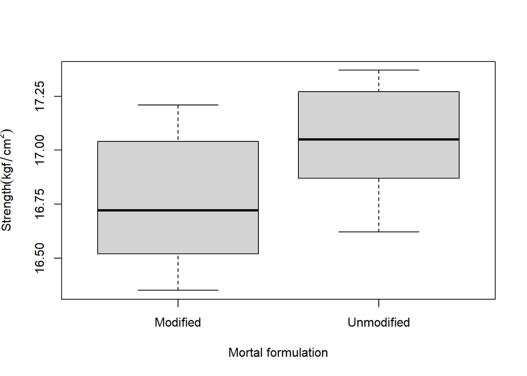

```r
y1 <- dat_2_1$y1 # Modified
y2 <- dat_2_1$y2 # Unmodified

boxplot(list('Modified'=y1, 'Unmodified'=y2),
        xlab='Mortal formulation',
        ylab=expression(Strength(kgf/cm^2)), yaxt='n')
axis(2, at=seq(16.50, 17.5, by=0.25))
```

## Hypothesis Testing Framework

### 1) Estimates the population mean

```r
y1_bar = mean(y1); y1_bar
```

```
[1] 16.764
```

```r
y2_bar = mean(y2); y2_bar
```

```
[1] 17.042
```

```r
n1 <- length(y1)
n2 <- length(y2)
sum(y1)/n1
```

```
[1] 16.764
```

```r
sum(y2)/n2
```

```
[1] 17.042
```

### 2) Estimates the population variance

```r
y1_sig2 = var(y1); y1_sig2
```

```
[1] 0.1001378
```

```r
y2_sig2 = var(y2); y2_sig2
```

```
[1] 0.06146222
```

```r
sum((y1 - y1_bar)^2)/(n1-1)
```

```
[1] 0.1001378
```

```r
sum((y2 - y2_bar)^2)/(n2-1)
```

```
[1] 0.06146222
```

### 3) Estimates the population standard deviation

```r
y1_sig = sd(y1); y1_sig
```

```
[1] 0.3164455
```

```r
y2_sig = sd(y2); y2_sig
```

```
[1] 0.2479158
```

```r
sqrt(y1_sig2)
```

```
[1] 0.3164455
```

```r
sqrt(y2_sig2)
```

```
[1] 0.2479158
```

## Probability distribution

1. r-distribution: 해당 분포를 따르는 난수 생성
2. d-distribution: 확률밀도함수의 값을 반환
3. p-distribution (cdf): 누적 확률을 계산
4. q-distribution(Quantile function): 분위수를 계산

### 1) Generate random numbers from such distribution

```r
set.seed(1)
x <- rnorm(n=10000, mean=0, sd=1) # x에 난수 저장
```

### 2) Density function

```r
dnorm(0, mean=0, sd=1) # 해당 x값에서 확률밀도함수의 y값 반환
```

```
[1] 0.3989423
```

```r
1/sqrt(2*pi)*exp(-(0)^2/2) # 실제 정규분포에 x=0대입
```

```
[1] 0.3989423
```

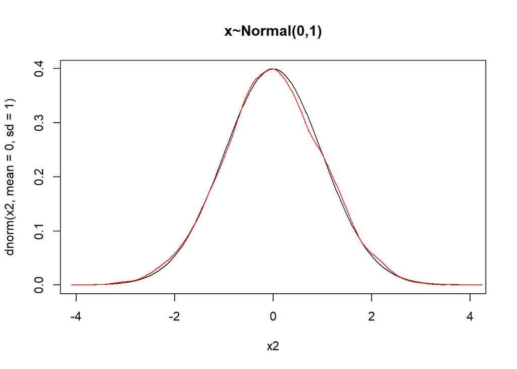

```r
x2 <- seq(-4, 4, length.out=1000) # -4, 4사이 1000개의 x 값
plot(x2, dnorm(x2, mean=0, sd=1), type='l', main='x~Normal(0,1)')
lines(density(x), col='red') # rnorm으로 만든 난수의 그래프
```

### 3) Cumulative Density function

**pnorm**

- lower.tail=F: 밑에 부터가 아닌 위에 부터 누적확률을 구함

```r
pnorm(1.96, mean=0, sd=1) # 해당 x값에서 누적밀도 함수값(누적확률) 반환
```

```
[1] 0.9750021
```

### 4) Quantile function

**qnorm**

- lower.tail=F: 밑에 부터가 아닌 위에 부터 누적확률을 적용

```r
qnorm(0.975, mean=0, sd=1) # 해당 확률에서의 x값을 반환
```

```
[1] 1.959964
```

```r
qnorm(0.025, mean=0, sd=1)
```

```
[1] -1.959964
```

## Hypothesis Testing Framework

### 1) If the variances are know

$$If \; \sigma=\sigma_{1}=\sigma_{2}=0.3 \qquad H_{0}:\mu_{1}=\mu_{2}, \ H_{1}:\mu_{1}\neq\mu_{2} \qquad Z_{0} = \frac{\overline{y_{1}}-\overline{y_{2}}}{\sqrt{\frac{\sigma_2^1}{n_{1}}+{\frac{\sigma_2^2}{n_{2}}}}}$$

Test statistics: Z0 (two-side test)

If sigma = sigma1 = sigma2 = 0.3

1. 기각역을 통한 검정 |Z(alpha/2)| < |Z0| 이면 기각 (결과: H0 기각)

```r
z0 = (y1_bar - y2_bar) / sqrt(0.3^2 * (1/n1 + 1/n2)); z0 # 검정 통계량
```

```
[1] -2.07209
```

```r
qnorm(0.025) # alpha = 0.05에서 기각역 Z0.025(df) = -1.95(양측 검정)
```

```
[1] -1.959964
```

2. 유의 수준을 통한 검정 alpha = 0.05 > p-value 이면 기각 (결과: H0 기각)

```r
2*pnorm(z0) # p-value = 0.038 (양측 검정)
```

```
[1] 0.03825708
```

3. 패키지를 이용한 검정

```r
# Using BSDA Package
# install.packages('BSDA')
library(BSDA)
z.test(y1, y2, sigma.x=0.3, sigma.y=0.3) # H0 기각(H1 채택, alternative hypothesis: y1 - y2 != 0)
```

```
    Two-sample z-Test

data:  y1 and y2
z = -2.0721, p-value = 0.03826
alternative hypothesis: true difference in means is not equal to 0
95 percent confidence interval:
 -0.54095676 -0.01504324
sample estimates:
mean of x mean of y
   16.764    17.042
```

### 2) If the variances are unknown(대부분의 경우)

Case1: Large Sample Size

$$H_{0}:\mu_{1}=\mu_{2}, \ H_{1}:\mu_{1}\neq\mu_{2} \qquad Z_{0} = \frac{\overline{y_{1}}-\overline{y_{2}}}{\sqrt{\frac{S_2^1}{n_{1}}+{\frac{S_2^2}{n_{2}}}}}$$

n > 30 => Sample sizes were large enough => Z-test

1. 기각역을 통한 검정 |Z(alpha/2)| < |Z0| 이면 기각 (결과: H0 기각)

```r
z0 = (y1_bar - y2_bar) / sqrt(y1_sig2/n1 + y2_sig2/n2); z0 # 검정 통계량
```

```
[1] -2.186876
```

```r
qnorm(0.025) # alpha = 0.05에서 기각역 Z0.025(df) = -1.95(양측 검정)
```

```
[1] -1.959964
```

2. 유의 수준을 통한 검정 alpha = 0.05 > p-value 이면 기각 (결과: H0 기각)

```r
2*pnorm(z0) # p-value = 0.038 (양측 검정)
```

```
[1] 0.02875159
```

Case2 1: Small Sample Size, $\sigma_1^2 = \sigma_2^2$ (크기가 작고 모분산이 같은 경우)

1. 기각역을 통한 검정 |t(alpha/2)| < |t0| 이면 기각 (결과: H0 기각)

```r
n = n1 + n2 - 2 # 자유도
s_pool2 = ((n1-1)*y1_sig2 + (n2-1)*y2_sig2)/n # Sp^2
t0 = (y1_bar-y2_bar) / (sqrt(s_pool2) * sqrt(1/n1 + 1/n2)); t0 # 검정 통계량
```

```
[1] -2.186876
```

```r
qt(0.025,n) # alpha = 0.05에서 기각역 t0.025(df) = -1.95(양측 검정)
```

```
[1] -2.100922
```

2. 유의 수준을 통한 검정 alpha = 0.05 > p-value 이면 기각 (결과: H0 기각)

```r
2*pt(t0,n) # p-value = 0.038 (양측 검정)
```

```
[1] 0.04219672
```

3. 함수를 이용한 검정

```r
t_res <- t.test(y1, y2, alternative = 'two.sided', var.equal = T) # alternativ: 검정 형태(y1, y2가 'tow.sided'(같다),'greater','less'), var.equal: 분산이 같은가 가정 여부
t_res # H0 기각(H1 채택, alternative hypothesis: y1 - y2 != 0)
```

```
    Two Sample t-test

data:  y1 and y2
t = -2.1869, df = 18, p-value = 0.0422
alternative hypothesis: true difference in means is not equal to 0
95 percent confidence interval:
 -0.54507339 -0.01092661
sample estimates:
mean of x mean of y
   16.764    17.042
```

```r
# 검정한 특정 값만 가져오기
t_res$statistic # t statistic
```

```
        t
-2.186876
```

```r
t_res$conf.int[1:2] # 95% confidence interval
```

```
[1] -0.54507339 -0.01092661
```

```r
t_res$p.value # p-value
```

```
[1] 0.04219672
```

4. 95% confidence interval(95% 신뢰구간 )

   (추정량 - t값 * 추정된 표준오차, 추정량 + t값 * 추정된 표준오차)

```r
diff = y1_bar - y2_bar # 추정량

t = qt(0.025, df = n, lower.tail = F); t
```

```
[1] 2.100922
```

```r
interval = t * (sqrt(s_pool2) * sqrt(1/n1 + 1/n2))

c(diff - interval, diff + interval)
```

```
[1] -0.54507339 -0.01092661
```

case 2-2 Small Sample Size, $\sigma_1^2 \neq \sigma_2^2$ (크기가 작고 모분산이 다른 경우)

$$t_{0} = \frac{\overline{y_{1}}-\overline{y_{2}}}{\sqrt{\frac{S_1^2}{n_{1}}+{\frac{S_2^2}{n_{2}}}}} \qquad v=\frac{{(\frac{S_1^2}{n_{1}}+\frac{S_2^2}{n_{2}})^2}}{\frac{(S_1^2/n_1)^2}{n_{1}-1}+\frac{(S_2^2/n_2)^2}{n_{2}-1}}$$

n < 30 (Sample sizes were small) & sigma1 != sigma2

1. 기각역을 통한 검정 |t(alpha/2)| < |t0| 이면 기각 (결과: H0 기각)

```r
t0 = (y1_bar-y2_bar) / sqrt(y1_sig2/n1 + y2_sig2/n2); t0 # 검정 통계량
```

```
[1] -2.186876
```

```r
qt(0.025,n) # alpha = 0.05에서 기각역 t0.025(df) = -1.95(양측 검정)
```

```
[1] -2.100922
```

```r
v = ((y1_sig2/n1) + (y2_sig2/n2))^2 /
  (((y1_sig2/n1)^2 / (n1-1)) + ((y2_sig2/n2)^2 / (n2-1))); v # 공분산
```

```
[1] 17.02485
```

2. 함수를 이용한 검정

```r
t_res2 <- t.test(y1, y2, alternative = 'two.sided', var.equal = F); t_res2 # H0 기각(H1 채택, alternative hypothesis: y1 - y2 != 0)
```

```
    Welch Two Sample t-test

data:  y1 and y2
t = -2.1869, df = 17.025, p-value = 0.043
alternative hypothesis: true difference in means is not equal to 0
95 percent confidence interval:
 -0.546174139 -0.009825861
sample estimates:
mean of x mean of y
   16.764    17.042
```

```r
# 검정한 특정 값만 가져오기
t_res2$parameter # d.f.
```

```
      df
17.02485
```

### 3) Tests on Variance of Normal Distribution

Case 1: One-sample test on variance of Normal Distribution

$$H_0:\sigma^2=\sigma_0^2 \qquad \chi_0^2=\frac{(n-1)S^2}{\sigma_0^2}$$

1. 공식을 이용해 검정

```r
chisq0 = ((n1-1) * y1_sig2) / 0.15; chisq0
```

```
[1] 6.008267
```

2. 패키지를 이용해 검정

```r
# install.packages('EnvStats')
library(EnvStats)
res = varTest(y1, alternative='less', sigma.squared=0.15); res # H0 기각하지 못함(H1 기각, sigma1^2 = 0.15)
```

```
    Chi-Squared Test on Variance

data:  y1
Chi-Squared = 6.0083, df = 9, p-value = 0.2609
alternative hypothesis: true variance is less than 0.15
95 percent confidence interval:
 0.0000000 0.2710404
sample estimates:
 variance
0.1001378
```

```r
# H0 : sigma2^2 = 0.05 vs H1 : sigma2^2 > 0.05
varTest(y2, alternative = 'greater', sigma.squared = 0.05) # H0 기각하지 못함(H1 기각, sigma2^2 = 0.05)
```

```
    Chi-Squared Test on Variance

data:  y2
Chi-Squared = 11.063, df = 9, p-value = 0.2714
alternative hypothesis: true variance is greater than 0.05
95 percent confidence interval:
 0.03269465        Inf
sample estimates:
  variance
0.06146222
```

Case2: Two sample test on variance of Normal Distribution

$$H_0:\sigma_1^2=\sigma_2^2,\ H_1:\sigma_1^2\neq\sigma_2^2 \qquad F_0=\frac{S_1^2}{S_2^2}$$

앞에서 n이 작은 모평균 검정 시, 이 모분산이 같다는 가정을 먼저 시행함

(등분산 가정이 필요한 If the variances are unknown 2-1 상황과 연계 중요)

```r
f0 = y1_sig2/y2_sig2; f0 # 검정 통계량
```

```
[1] 1.629257
```

```r
var.test(y1, y2, alternative = 'two.sided') # H0 기각하지 못함(sigma1^2 = sigma2^2)
```

```
    F test to compare two variances

data:  y1 and y2
F = 1.6293, num df = 9, denom df = 9, p-value = 0.4785
alternative hypothesis: true ratio of variances is not equal to 1
95 percent confidence interval:
 0.4046845 6.5593806
sample estimates:
ratio of variances
          1.629257
```

$H_0:\sigma_1^2=2\sigma_2^2,\ H_1:\sigma_1^2\neq2\sigma_2^2$

```r
x1 <- rnorm(100, 0, sqrt(2)) # 3번째 자리는 표준편차 아래 분산의 2배
x2 <- rnorm(100, 0, 1)
var.test(x1, x2, ratio=2, alternative='two.sided') # H0 기각하지 못함(sigma1^2 = 2 * sigma2^2) # ratio: var.test의 H1에서 검정하는 분산의 비율 여기선 2:1, sigma1 = 2 * sigma2
```

```
    F test to compare two variances

data:  x1 and x2
F = 0.733, num df = 99, denom df = 99, p-value = 0.124
alternative hypothesis: true ratio of variances is not equal to 2
95 percent confidence interval:
 0.9863875 2.1788224
sample estimates:
ratio of variances
          1.466002
```

# Chapter 3 Analysis of Variance

Example 3.1: Etch Rate Data

4 levels of RF power : (160W, 180W, 200W, 220W)

Replicated 5 times : (1, 2, 3, 4, 5) (runs made in random order)

- data

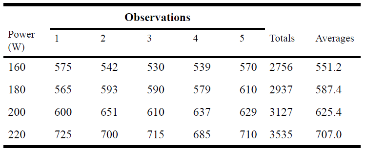

```r
power <- factor(c(160,180,200,220)); power # 레벨
```

```
[1] 160 180 200 220
Levels: 160 180 200 220
```

```r
times <- factor(c(1,2,3,4,5)); times
```

```
[1] 1 2 3 4 5
Levels: 1 2 3 4 5
```

```r
dat <- expand.grid(times=times, power=power); dat # 수준 조합
```

```
   times power
1      1   160
2      2   160
3      3   160
4      4   160
5      5   160
6      1   180
7      2   180
8      3   180
9      4   180
10     5   180
11     1   200
12     2   200
13     3   200
14     4   200
15     5   200
16     1   220
17     2   220
18     3   220
19     4   220
20     5   220
```

```r
etch_rate <- c(575,542,530,539,570,
               565,593,590,579,610,
               600,651,610,637,629,
               725,700,715,685,710)

dat$etch <- etch_rate; dat # 데이터에 삽입
```

```
   times power etch
1      1   160  575
2      2   160  542
3      3   160  530
4      4   160  539
5      5   160  570
6      1   180  565
7      2   180  593
8      3   180  590
9      4   180  579
10     5   180  610
11     1   200  600
12     2   200  651
13     3   200  610
14     4   200  637
15     5   200  629
16     1   220  725
17     2   220  700
18     3   220  715
19     4   220  685
20     5   220  710
```

etch data의 $y_{i.},\ \overline{y_{i.}}$ (row 합, 평균) 구하기

1. for 문을 이용

```r
## Method 1
y_idot <- rep(0,4)
y_idotbar <- rep(0,4)

for(i in 1:4){
  y_idot[i] = sum(dat$etch[dat$power==levels(dat$power)[i]]) # levels(): 해당 값의 레벨을 가져옴
  y_idotbar[i] = mean(dat$etch[dat$power==levels(dat$power)[i]])
}

y_idot
```

```
[1] 2756 2937 3127 3535
```

```r
y_idotbar
```

```
[1] 551.2 587.4 625.4 707.0
```

2. tapply이용

```r
## Method 2
y_idot2 <- tapply(dat$etch, dat$power, function(x) sum(x))
y_idot2
```

```
 160  180  200  220
2756 2937 3127 3535
```

```r
y_idotbar2 <- tapply(dat$etch, dat$power, function(x) mean(x))
y_idotbar2
```

```
  160   180   200   220
551.2 587.4 625.4 707.0
```

Box plot & Scatter plot

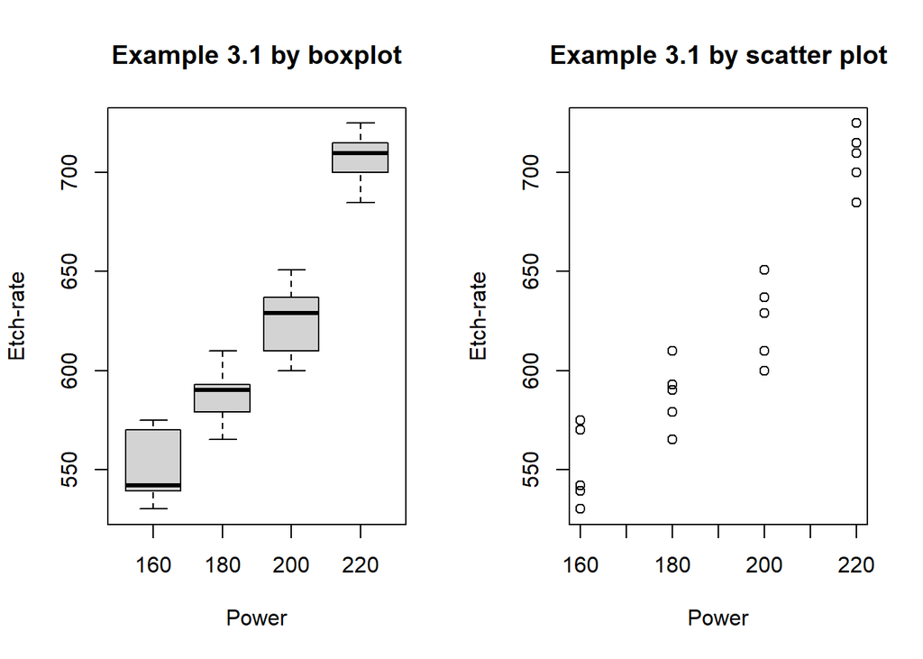

```r
par(mfrow=c(1,2))

# Box plot(factor ~ factor)
plot(dat$etch ~ dat$power,
     main = 'Example 3.1 by boxplot',
     xlab = 'Power', ylab = 'Etch-rate')

# Scatter plot(factor ~ character)
plot(dat$etch ~ as.character(dat$power),
     main = 'Example 3.1 by scatter plot',
     xlab = 'Power', ylab = 'Etch-rate')
```

## Completely Randomized Design (CRD)

- **a** levels or treatments
- **n** replicates
- Run in random order
- There are fixed effects case

  (Fixed Effects Model(CRD, etc): treatment는 이미 정해진 상황에서 실험 순서를 random으로 진행한다. <-> Random Effects Model은 treatment를 random하게 선택한다.)
- The goal is to test hypotheses about the equality of the 𝑎treatment means

### 1) One Way ANOVA model

- effects model: $\mu_{ij} = \mu + \tau_i + \epsilon_{ij}$
- Formal Statistical Hypothesis: $H_0:\tau_1=…=\tau_a=0, \ H1:At \ least \ one \ is \ different$
- Decomposition of the Total Sum of Squares (SS):

  $$\sum_{i=1}^a\sum_{j=1}^n(y_{ij}-\overline{y}_{..})^2 = n\sum_{i=1}^a(y_{i.}-\overline{y}_{..})^2 + \sum_{i=1}^a\sum_{j=1}^n(y_{ij}-\overline{y}_{i.})^2 \\SS_T = SS_{Treatments} + SS_E$$
- ANOVA table

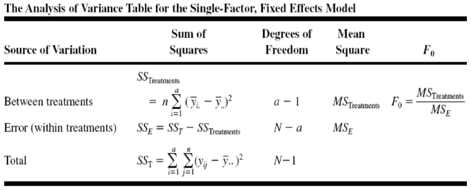

- aov를 이용해서 CRD 분석(권장)

```r
## One-way ANOVA
fit_etch <- aov(etch ~ power, data=dat) # 분산분석
anova(fit_etch)
```

```
Analysis of Variance Table

Response: etch
          Df Sum Sq Mean Sq F value    Pr(>F)
power      3  66871 22290.2  66.797 2.883e-09 ***
Residuals 16   5339   333.7
---
Signif. codes:  0 '***' 0.001 '**' 0.01 '*' 0.05 '.' 0.1 ' ' 1
```

```r
summary(fit_etch)
```

```
            Df Sum Sq Mean Sq F value   Pr(>F)
power        3  66871   22290    66.8 2.88e-09 ***
Residuals   16   5339     334
---
Signif. codes:  0 '***' 0.001 '**' 0.01 '*' 0.05 '.' 0.1 ' ' 1
```

2. lm을 이용해서 CRD 분석(권장하지 않음)

```r
# If is same as aov function if treatment's(power) value type is factor
# 분산분석을 원하면 lm보단 aov로 하는게 좋다
fit_etch2 <- lm(etch ~ power, data=dat) # 원하는 결과
anova(fit_etch2)
```

```
Analysis of Variance Table

Response: etch
          Df Sum Sq Mean Sq F value    Pr(>F)
power      3  66871 22290.2  66.797 2.883e-09 ***
Residuals 16   5339   333.7
---
Signif. codes:  0 '***' 0.001 '**' 0.01 '*' 0.05 '.' 0.1 ' ' 1
```

```r
summary(fit_etch2)
```

```
Call:
lm(formula = etch ~ power, data = dat)

Residuals:
   Min     1Q Median     3Q    Max
 -25.4  -13.0    2.8   13.2   25.6

Coefficients:
            Estimate Std. Error t value Pr(>|t|)
(Intercept)  551.200      8.169  67.471  < 2e-16 ***
power180      36.200     11.553   3.133  0.00642 **
power200      74.200     11.553   6.422 8.44e-06 ***
power220     155.800     11.553  13.485 3.73e-10 ***
---
Signif. codes:  0 '***' 0.001 '**' 0.01 '*' 0.05 '.' 0.1 ' ' 1

Residual standard error: 18.27 on 16 degrees of freedom
Multiple R-squared:  0.9261,    Adjusted R-squared:  0.9122
F-statistic:  66.8 on 3 and 16 DF,  p-value: 2.883e-09
```

```r
fit_etch3 <- lm(etch ~ as.numeric(as.character(power)), data=dat) # factor가 아닌 수치형 자료여서 aov와 다른결과
anova(fit_etch3)
```

```
Analysis of Variance Table

Response: etch
                                Df Sum Sq Mean Sq F value    Pr(>F)
as.numeric(as.character(power))  1  63857   63857  137.62 7.263e-10 ***
Residuals                       18   8352     464
---
Signif. codes:  0 '***' 0.001 '**' 0.01 '*' 0.05 '.' 0.1 ' ' 1
```

```r
summary(fit_etch3)
```

```
Call:
lm(formula = etch ~ as.numeric(as.character(power)), data = dat)

Residuals:
   Min     1Q Median     3Q    Max
-43.02 -12.32  -1.21  16.71  33.06

Coefficients:
                                Estimate Std. Error t value Pr(>|t|)
(Intercept)                     137.6200    41.2108   3.339  0.00365 **
as.numeric(as.character(power))   2.5270     0.2154  11.731 7.26e-10 ***
---
Signif. codes:  0 '***' 0.001 '**' 0.01 '*' 0.05 '.' 0.1 ' ' 1

Residual standard error: 21.54 on 18 degrees of freedom
Multiple R-squared:  0.8843,    Adjusted R-squared:  0.8779
F-statistic: 137.6 on 1 and 18 DF,  p-value: 7.263e-10
```

factor형 -> 수치형 변환

```r
dat$power
```

```
 [1] 160 160 160 160 160 180 180 180 180 180 200 200 200 200 200 220 220 220 220
[20] 220
Levels: 160 180 200 220
```

```r
as.numeric(dat$power) # 바로 수치형으로 변환하면 다른 결과가 나온다
```

```
 [1] 1 1 1 1 1 2 2 2 2 2 3 3 3 3 3 4 4 4 4 4
```

```r
as.numeric(as.character((dat$power))) # 문자형 변경 후 수치형 변경 시 원하는 결과를 얻음
```

```
 [1] 160 160 160 160 160 180 180 180 180 180 200 200 200 200 200 220 220 220 220
[20] 220
```

3. Sum of Square

```r
SS_vec <- anova(fit_etch)$'Sum Sq'; SS_vec
```

```
[1] 66870.55  5339.20
```

```r
SS_total <- sum(SS_vec)
SS_treat <- SS_vec[1]
SS_error <- SS_vec[2]
SS_total; SS_treat; SS_error
```

```
[1] 72209.75
```

```
[1] 66870.55
```

```
[1] 5339.2
```

### 2) Model Adequacy Checking in the ANOVA

#### Checking normal assumption(정규성 가정)

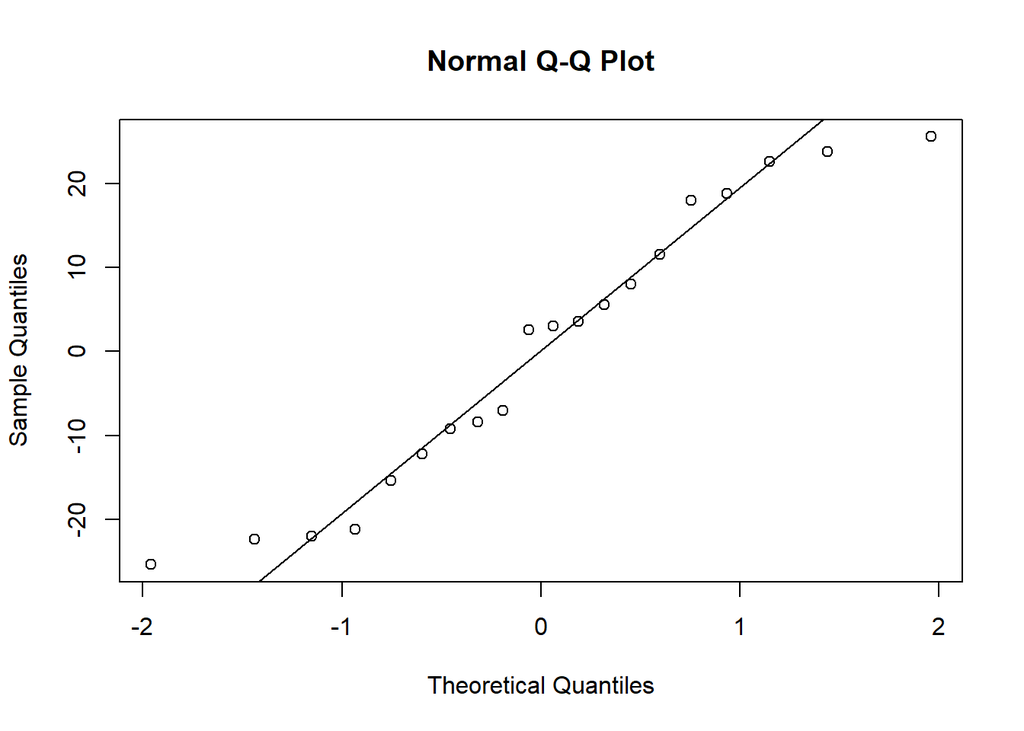

```r
# Method 1
# Q-Q Plot
# 직선상에 존재하면 정규성을 만족
par(mfrow = c(1,1))
qqnorm(fit_etch$residuals)
qqline(fit_etch$residuals)
```

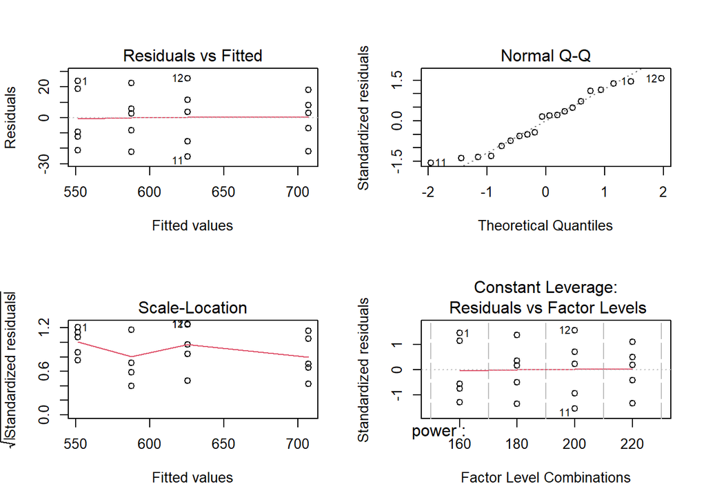

```r
# Method 2
# aov 적합값을 plot으로 바로 그리면 Nomal Q-Q plot을 제공
par(mfrow = c(2,2))
plot(fit_etch)
```

```r
# Method 3
# Shapiro Wilk test
# H0:정규분포를 따른다 vs H1:정규분포를 따르지 않는다.
shapiro.test(fit_etch$residuals) # H0를 기각할 수 없다.
```

```
    Shapiro-Wilk normality test

data:  fit_etch$residuals
W = 0.93752, p-value = 0.2152
```

#### Plot of residuals versus run order or time(독립성 가정)

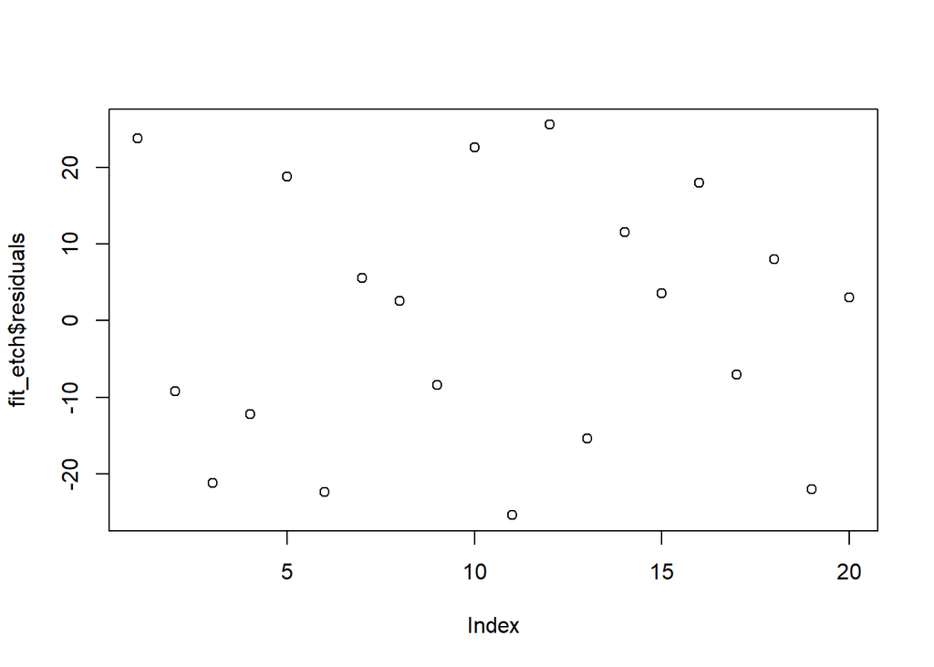

```r
# Check for residual plots
# 기존 잔차들의 plot
par(mfrow = c(1,1))
plot(fit_etch$residuals)
```

```r
# 잔차 순서를 랜덤하게 변경
set.seed(1)
spl_idx <- sample(1:20, 20); spl_idx
```

```
 [1]  4  7  1  2 13 19 11 17 14  3 18  5  9 16  6 15 12 10 20  8
```

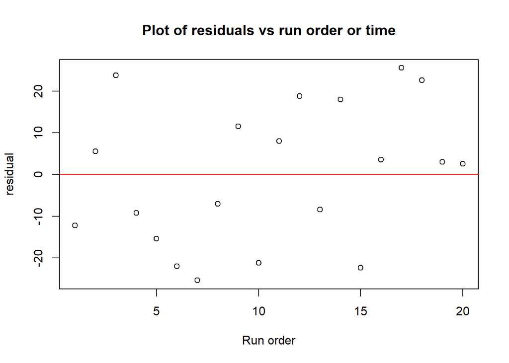

```r
# 잔차 순서를 랜덤하게 고려한 plot
# 특정한 패턴을 확인할 수 없다(독립성 가정 만족)
plot(fit_etch$residuals[spl_idx],
     main = 'Plot of residuals vs run order or time',
     ylab = 'residual', xlab = 'Run order')
abline(h=0, col='red')
```

#### Constrant variance(등분산 가정)

```r
# Levene’s test
# install.packages('lawstat')
library(lawstat)

## H0: The k group variances are equal.
levene.test(dat$etch, dat$power, location ='mean')
```

```
    Classical Levene's test based on the absolute deviations from the mean
    ( none not applied because the location is not set to median )

data:  dat$etch
Test Statistic = 0.54086, p-value = 0.6612
```

### 3) Factors: Qualitative or Quantitative

- 정량적 요인인 경우 회귀 모형을 고려
- 질적 요인인 경우 다중 비교를 고려

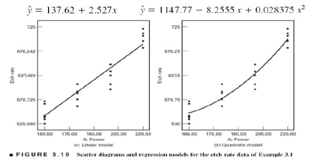

```r
## Numeric Power Regression models
# Linear anova
# (중요)factor는 character로 변경 후 numeric으로 변경해 사용
dat$num_power <- as.numeric((as.character((dat$power))))

fit_reg <- lm(etch ~ num_power, data=dat)
summary(fit_reg)
```

```
Call:
lm(formula = etch ~ num_power, data = dat)

Residuals:
   Min     1Q Median     3Q    Max
-43.02 -12.32  -1.21  16.71  33.06

Coefficients:
            Estimate Std. Error t value Pr(>|t|)
(Intercept) 137.6200    41.2108   3.339  0.00365 **
num_power     2.5270     0.2154  11.731 7.26e-10 ***
---
Signif. codes:  0 '***' 0.001 '**' 0.01 '*' 0.05 '.' 0.1 ' ' 1

Residual standard error: 21.54 on 18 degrees of freedom
Multiple R-squared:  0.8843,    Adjusted R-squared:  0.8779
F-statistic: 137.6 on 1 and 18 DF,  p-value: 7.263e-10
```

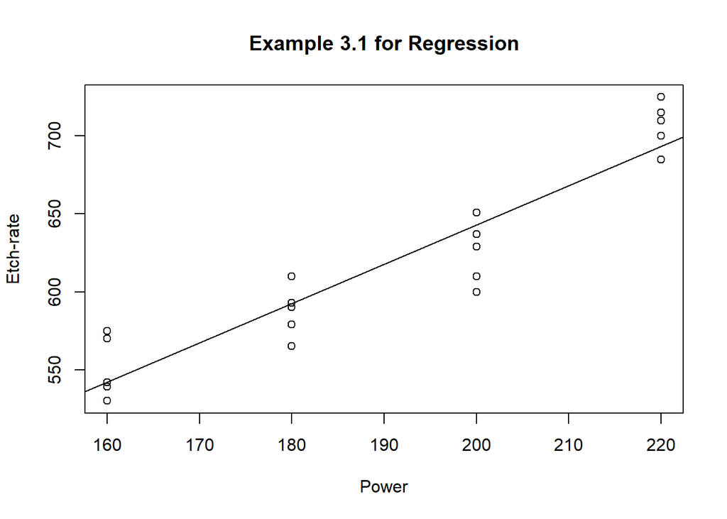

```r
# Linear 그래프
par(mfrow=c(1,1))
plot(dat$etch ~ dat$num_power,
     main = 'Example 3.1 for Regression',
     xlab = 'Power', ylab = 'Etch-rate')
abline(fit_reg)
```

```r
# Quadratic anova
fit_reg2 <- lm(etch ~ num_power + I(num_power^2),data = dat)
summary(fit_reg2)
```

```
Call:
lm(formula = etch ~ num_power + I(num_power^2), data = dat)

Residuals:
   Min     1Q Median     3Q    Max
-31.67 -14.75   1.48  13.08  28.87

Coefficients:
                 Estimate Std. Error t value Pr(>|t|)
(Intercept)    1147.77000  368.52081   3.115  0.00631 **
num_power        -8.25550    3.91993  -2.106  0.05037 .
I(num_power^2)    0.02838    0.01030   2.754  0.01356 *
---
Signif. codes:  0 '***' 0.001 '**' 0.01 '*' 0.05 '.' 0.1 ' ' 1

Residual standard error: 18.43 on 17 degrees of freedom
Multiple R-squared:   0.92, Adjusted R-squared:  0.9106
F-statistic: 97.76 on 2 and 17 DF,  p-value: 4.74e-10
```

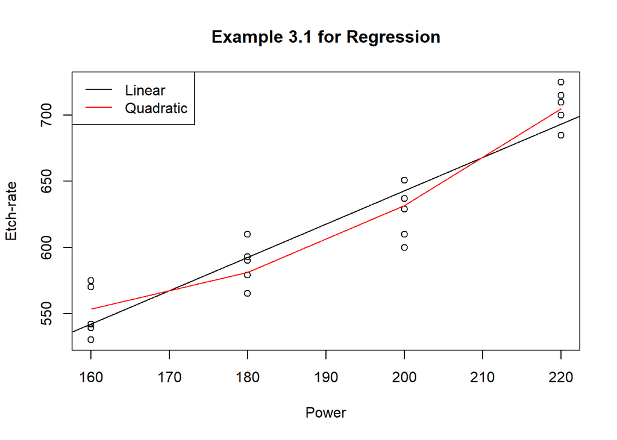

```r
# Quadratic with Linear그래프
par(mfrow=c(1,1))
plot(dat$etch ~ dat$num_power,
     main = 'Example 3.1 for Regression',
     xlab = 'Power', ylab = 'Etch-rate')
abline(fit_reg)

lines(dat$num_power, y=fit_reg2$fitted.values, col='red')
legend('topleft', legend = c('Linear','Quadratic'),
       col=c('black','red'), lty=c(1,1))
```

## After ANOVA

ANOVA분석에서 H0 reject에 성공 했을 시 어떤 factor, factor간 interaction이 유의해서 H0를 reject할 수 있었는지 model을 factor별로 분해해 ANOVA로 확인하는 과정

### 1) Contrasts

- Contrasts is a linear combination of parameters of the form($C_i$는 $\mu_i$앞의 상수)

$$\tau = \sum_{i=1}^ac_i\mu_i \quad where \ \sum_{i=1}^ac_i=0$$

- Hypotheses set up prior to the running of experiment(원하는 조합의 $c_i\mu_i$ 합이 0인가에 관심)

$$H_0:\sum_{i=1}^ac_i\mu_i=0 \quad (\leftarrow\tau=0)$$

- 통계량

$$F = \frac{MS_C}{MS_E}=\frac{SS_C/1}{MS_E}\sim F_{\alpha,1,N-a} \quad where \ SS_C=\frac{(\sum_i^ac_i\overline{\mu_i})^2}{(1/n)\sum c_i^2} \; with \; df = 1$$

#### Orthogonal Contrasts

- Definition : Two contrasts with coefficients $c_i$and $d_i$are orthogonal if

  (각각의 contrasts의 $\mu_i$앞 같은 위치 상수 $c_i, d_i$끼리의 곱의 합이 0이면 orthogonal하다)

$$\sum_{i=1}^ac_id_i=0$$

- a개의 treatment에서는 최대 (a-1)개의 orthogonal contrasts partition이 생길 수 있다.

  partitioning된 orthogonal contrasts의 $SS_C, df_C$의 합은 $SS_{treatment}, df_{treatment}$가 된다.

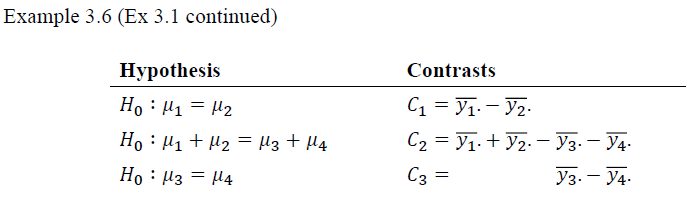

- ANOVA table

[figure not shown]

1. 데이터 정의

```r
power = factor(c(160,180,200,220))
times = factor(c(1,2,3,4,5))

dat = expand.grid(times=times, power=power)

dat$value = c(575,542,530,539,570,
              565,593,590,579,610,
              600,651,610,637,629,
              725,700,715,685,710)
```

```r
# power factor에 contrast 생성
c_mat = matrix(c(1,-1,0,0,
                 1,1,-1,-1,
                 0,0,1,-1),ncol=3) # 검정하고자 싶은 가설을 colum 단위로 넣어줘야함

contrasts(dat$power, 3) = c_mat # power factor에 contrasts 3개를 저장
dat$power
```

```
 [1] 160 160 160 160 160 180 180 180 180 180 200 200 200 200 200 220 220 220 220
[20] 220
attr(,"contrasts")
    [,1] [,2] [,3]
160    1    1    0
180   -1    1    0
200    0   -1    1
220    0   -1   -1
Levels: 160 180 200 220
```

2. orthogonal contrasts anova(기본 aov는 partitioning 된 값을 보여주지 않는다.)

```r
fit_cont = aov(value ~ power, data=dat)
anova(fit_cont)
```

```
Analysis of Variance Table

Response: value
          Df Sum Sq Mean Sq F value    Pr(>F)
power      3  66871 22290.2  66.797 2.883e-09 ***
Residuals 16   5339   333.7
---
Signif. codes:  0 '***' 0.001 '**' 0.01 '*' 0.05 '.' 0.1 ' ' 1
```

aov

- split: contrast에 따라 검정을 분해하는 기능

```r
# split 할 항목 이름을 지정
power_list = list('c1: mu_1 = mu_2' = 1,
                  'c2: mu_1 + mu_2 = mu_3 + mu_4' = 2,
                  'c3: mu_3 = mu_4' = 3)

summary.aov(fit_cont, split = list(power=power_list)) # 각 contrast로 분해한 anova
```

```
                                       Df Sum Sq Mean Sq F value   Pr(>F)
power                                   3  66871   22290  66.797 2.88e-09 ***
  power: c1: mu_1 = mu_2                1   3276    3276   9.818  0.00642 **
  power: c2: mu_1 + mu_2 = mu_3 + mu_4  1  46948   46948 140.689 2.43e-09 ***
  power: c3: mu_3 = mu_4                1  16646   16646  49.884 2.68e-06 ***
Residuals                              16   5339     334
---
Signif. codes:  0 '***' 0.001 '**' 0.01 '*' 0.05 '.' 0.1 ' ' 1
```

#### Scheffe’s Method

각각이 orthogonal contrasts조건을 만족하지 않더라도 검정 가능(최대 a-1개 초과 검정 가능)

그러나 검정 결과가 sensitive하지 않다.(잘 기각을 하지 못한다)

- Decision: Reject hypothesis H0:𝑐1𝑢𝜇1+⋯+𝑐𝑎𝑢𝜇𝑎=0

$$IF, \mid C_u\mid > S_{\alpha,u} \ where \ S_{\alpha,u} = S_{C_u}\sqrt{(a-1)F_{\alpha, a-1, N-a}}\\S_{C_u} = \sqrt{MS_E\sum_{i=1}^a(C^2_{iu}/n_i)},\ the \ Standard \ error \ of \ the \ contrast$$

scheffe.test 검정 결과 해석

- Scheffe: $S_{C_u}$값
- groups: contrast를 비슷한 값끼리 묶어줌

agricolae패키지 내 함수

```r
# install.packages('agricolae')
library(agricolae)
res_scheffe = scheffe.test(fit_cont, trt='power'); res_scheffe
```

```
$statistics
  MSerror Df        F   Mean       CV  Scheffe CriticalDifference
    333.7 16 3.238872 617.75 2.957095 3.117148           36.01352

$parameters
     test name.t ntr alpha
  Scheffe  power   4  0.05

$means
    value      std r Min Max Q25 Q50 Q75
160 551.2 20.01749 5 530 575 539 542 570
180 587.4 16.74216 5 565 610 579 590 593
200 625.4 20.52559 5 600 651 610 629 637
220 707.0 15.24795 5 685 725 700 710 715

$comparison
NULL

$groups
    value groups
220 707.0      a
200 625.4      b
180 587.4      c
160 551.2      d

attr(,"class")
[1] "group"
```

```r
plot(res_scheffe)
```

[output not shown]

### 2) Comparing Pairs of Treatment Means(쌍비교)

#### Fisher Least Significant Difference (LSD) Method

Use the t statistic for testing $𝐻0∶\mu_i−\mu_𝑗=0$ for all pairwise means

Reject H0 if

$$\mid \overline{\mu}_{i.}-\overline{\mu}_{j.} \mid \ > \ t_{\alpha/2, N-a}\sqrt{MS_E(1/n_i+1/n_j)}, \\ where \ LSD = t_{\alpha/2, N-a}\sqrt{MS_E(1/n_i+1/n_j)}$$

agricolae패키지 내 함수

```r
# LSD test 같은 경우엔 all pairwise means 에 대해 test 하지만
# family error rate을 원하는 유의수준으로 control하는게 불가능
# library(agricolae)
res_LSD = LSD.test(fit_cont, trt = 'power')
res_LSD
```

```
$statistics
  MSerror Df   Mean       CV  t.value      LSD
    333.7 16 617.75 2.957095 2.119905 24.49202

$parameters
        test p.ajusted name.t ntr alpha
  Fisher-LSD      none  power   4  0.05

$means
    value      std r      LCL      UCL Min Max Q25 Q50 Q75
160 551.2 20.01749 5 533.8815 568.5185 530 575 539 542 570
180 587.4 16.74216 5 570.0815 604.7185 565 610 579 590 593
200 625.4 20.52559 5 608.0815 642.7185 600 651 610 629 637
220 707.0 15.24795 5 689.6815 724.3185 685 725 700 710 715

$comparison
NULL

$groups
    value groups
220 707.0      a
200 625.4      b
180 587.4      c
160 551.2      d

attr(,"class")
[1] "group"
```

```r
plot(res_LSD)
```

[output not shown]

#### Tukey’s test

Reject H0 if

$$\mid \overline{\mu}_{i.}-\overline{\mu}_{j.} \mid \ > T_\alpha = q_\alpha(a,f)\sqrt{ME_E/n}, \\ where \ f \ is \ df \ of \ ME_E \ and \ q_\alpha(a,f) \\ is \ the \ upper \ \alpha \ percentile \ of \ q \ (q = (\overline{y}_{max} - \overline{y}_{min})/\sqrt{MS_E(1/n_i+1/n_j)})$$

1. agricolae 패키지 내 함수

```r
# family error rate 원하는 유의수준으로 control 가능
# library(agricolae)
res_Tukey = HSD.test(fit_cont, 'power')
res_Tukey
```

```
$statistics
  MSerror Df   Mean       CV      MSD
    333.7 16 617.75 2.957095 33.05438

$parameters
   test name.t ntr StudentizedRange alpha
  Tukey  power   4         4.046093  0.05

$means
    value      std r Min Max Q25 Q50 Q75
160 551.2 20.01749 5 530 575 539 542 570
180 587.4 16.74216 5 565 610 579 590 593
200 625.4 20.52559 5 600 651 610 629 637
220 707.0 15.24795 5 685 725 700 710 715

$comparison
NULL

$groups
    value groups
220 707.0      a
200 625.4      b
180 587.4      c
160 551.2      d

attr(,"class")
[1] "group"
```

```r
plot(res_Tukey)
```

[output not shown]

2. R 기본 함수

```r
res_Tukey2 = TukeyHSD(fit_cont, 'power', conf.level = 0.95)
res_Tukey2
```

```
  Tukey multiple comparisons of means
    95% family-wise confidence level

Fit: aov(formula = value ~ power, data = dat)

$power
         diff        lwr       upr     p adj
180-160  36.2   3.145624  69.25438 0.0294279
200-160  74.2  41.145624 107.25438 0.0000455
220-160 155.8 122.745624 188.85438 0.0000000
200-180  38.0   4.945624  71.05438 0.0215995
220-180 119.6  86.545624 152.65438 0.0000001
220-200  81.6  48.545624 114.65438 0.0000146
```

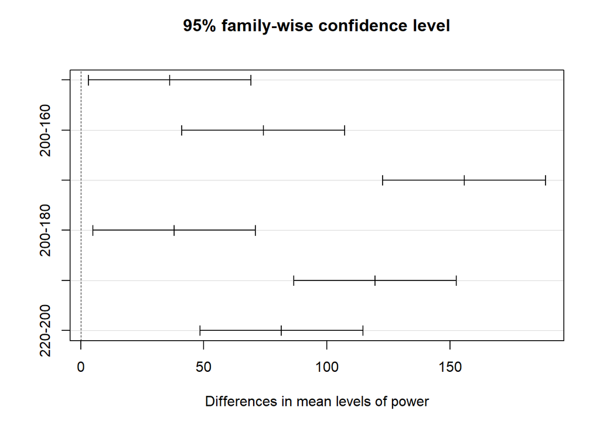

```r
plot(res_Tukey2)
```

### 3) Comparing with a control

Dunnett method: 대조를 위해 만든 조건을 control(대조군)이라고 하고, 그것과 나머지(a - 1개)의 treatment mean을 모두 비교

ex) 제약회사에서 약의 투약 효과를 확인 하기 위해, 신약 0mg, 10mg, 15mg, 20mg을 포함한 주사를 투약하는 실험을 진행한다. 여기서 0mg은 control인 위약이다. Comparing with a control에서는 위약의 결과 평균 대비 나머지 결과 평균을 모두 짝지어 비교한다.

$\mu_a$를 control level의 treatment mean이라고 하면

- Hypotheses: $H0: \mu_i = \mu_a \ vs \ H1:\mu_i \neq \mu_a \ for \ i=1,…,a-1$
- Reject H0 if: $\mid \overline{y}_{i.}-\overline{y}_{a.} \mid \ > \ d_\alpha(a-1,f)\sqrt{MS_E(1/n_i+1/n_a)}$

```r
# install.packages('DescTools')
library(DescTools)
DunnettTest(dat$value, dat$power, control='220', conf.level=0.95) # 220수준 값과 비교
```

```
  Dunnett's test for comparing several treatments with a control :
    95% family-wise confidence level

$`220`
          diff    lwr.ci     upr.ci    pval
160-220 -155.8 -185.7533 -125.84665 2.0e-10 ***
180-220 -119.6 -149.5533  -89.64665 1.3e-09 ***
200-220  -81.6 -111.5533  -51.64665 1.1e-05 ***

---
Signif. codes:  0 '***' 0.001 '**' 0.01 '*' 0.05 '.' 0.1 ' ' 1
```

## The random effects model

- The experimenter chooses 𝑎of these levels at random <-> Fixed Effects Model
- Model:
  $$y_{ij} = \mu+\tau_i+\epsilon_{ij}, \quad i = 1,2,…,a; \; j=1,2,…,n \\ Where \ both \tau_i \ and \ \epsilon_{ij} \ are \ random \ and \ independent$$
- Assumptions:

$$\tau_i\sim IN(0,\sigma^2_\tau) \ and \ \epsilon_{ij} \sim IN(0,\sigma^2) \ with \ \tau_i\perp\epsilon_{ij} \\ Note \ that \ Var(y_{ij}) = \sigma^2_\tau+\sigma^2 \ (Variance \ Components)$$

- Hypotheses:

$$H0: \sigma^2_\tau=0 \; vs \; H1:\sigma^2_\tau>0$$

- data

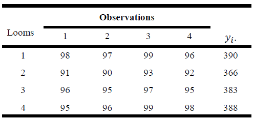

Random Effects Model data

```r
looms = factor(1:4)
times = factor(1:4)

dat_3_11 = expand.grid(times=times, looms=looms)

dat_3_11$value = c(98,97,99,96,
                   91,90,93,92,
                   96,95,97,95,
                   95,96,99,98)
```

ANOVA

```r
fit_re = aov(value ~ looms, data=dat_3_11)
res_re = anova(fit_re); res_re
```

```
Analysis of Variance Table

Response: value
          Df Sum Sq Mean Sq F value    Pr(>F)
looms      3 89.188 29.7292  15.681 0.0001878 ***
Residuals 12 22.750  1.8958
---
Signif. codes:  0 '***' 0.001 '**' 0.01 '*' 0.05 '.' 0.1 ' ' 1
```

- Estimating the model parameters(Variance Components):

$$E[MS_{treatment}]=\sigma^2+n\sigma^2_\tau \ and \ E[MS_E] = \sigma^2 \\\Rightarrow \widehat{\sigma}^2=MS_E, \quad\widehat{\sigma}^2_\tau=\frac{MS_{treatment}-MS_E}{n}$$

```r
sigma2 = res_re$'Mean Sq'[2]; sigma2
```

```
[1] 1.895833
```

```r
sigma_tau2 = (res_re$'Mean Sq'[1] - sigma2)/4; sigma_tau2
```

```
[1] 6.958333
```

- Confidence interval for the error variance:

$$\frac{(N-a)MS_E}{\chi^2_{\alpha/2,N-a}} \leq \sigma^2 \leq \frac{(N-a)MS_E}{\chi^2_{1-(\alpha/2),N-a}}$$

```r
12 * sigma2 / qchisq(0.975,12); 12 * sigma2 / qchisq(0.025,12)
```

```
[1] 0.9748608
```

```
[1] 5.166006
```

lme4 패키지를 이용한 ANOVA 분석

```r
# install.packages('lme4')
library(lme4)
fit_re2 <- lmer(value ~ (1|looms), data=dat_3_11); fit_re2 # random effect model
```

```
Linear mixed model fit by REML ['lmerMod']
Formula: value ~ (1 | looms)
   Data: dat_3_11
REML criterion at convergence: 63.193
Random effects:
 Groups   Name        Std.Dev.
 looms    (Intercept) 2.638
 Residual             1.377
Number of obs: 16, groups:  looms, 4
Fixed Effects:
(Intercept)
      95.44
```

```r
vc = as.data.frame(VarCorr(fit_re2)); vc
```

```
       grp        var1 var2     vcov    sdcor
1    looms (Intercept) <NA> 6.958334 2.637865
2 Residual        <NA> <NA> 1.895833 1.376893
```

```r
vc[1,4]; sigma_tau2
```

```
[1] 6.958334
```

```
[1] 6.958333
```

```r
vc[2,4]; sigma2
```

```
[1] 1.895833
```

```
[1] 1.895833
```

```r
confint(fit_re2, oldNames=F)
```

```
Computing profile confidence intervals ...
```

```
                          2.5 %    97.5 %
sd_(Intercept)|looms  1.1293759  5.748927
sigma                 0.9672533  2.184005
(Intercept)          92.4393299 98.435668
```

# Chapter 4 Experiments with Blocking Factors

## The Randomized Complete Block Design (RCBD)

### The Blocking Principle

- A nuisance factor is a factor that probably has some effect on the response, but it’s of no

  interest
- Blocking is a technique for dealing with nuisance factors
- If the nuisance variable is known and controllable

  → Use blocking, Randomized Complete Block Design (RCBD
- If the factor is known and uncontrollable

  → Use analysis of covariance
- If the factor is unknown and uncontrollable a “lurking” variable

  → Randomization balances out its impact across the experiment

### Statistical Analysis of the RCBD

- A Statistical Model ( effects model ) for the:

$$y_{ij} = \mu + \tau_i + \beta_j + \epsilon_{ij}, \quad i=1,2,…,a; \; j=1,2,…,b$$

Where $\mu$is an overall mean, $\tau_i$is the effect of $i$ th treatment, $\beta_j$is the effect of $j$ th block

- Assumptions (for Fixed Factors):

$$\sum_{i=1}^a\tau_i=0 \; and \; \sum_{j=1}^b\beta_j=0 \; with \; \epsilon_{ij}\sim IN(0,\sigma^2)$$

- Hypothesis:

$$H0:\mu_1=\mu_2=…=\mu_a \; vs \; H1:at \ least \ one \ \mu_i\neq \mu_j\\where \ \mu_i=(1/b)\sum_{j=1}^b(\mu + \tau_i + \beta_j)=\mu+\tau_i \\\leftrightarrow H0:\tau_1=\tau_2=…=\tau_a=0 \; vs \; H1:\tau_i \neq 0 \ at \ least \ one \ i$$

- ANOVA table

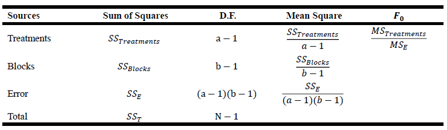

- 통계량

  $$Test \ Static: F_0 = \frac{MS_{Treatments}}{MS_E}\sim F_{\alpha,a-1,(a-1)(b-1)} \quad under \; H_0:\tau_1=…=\tau_a\\\rightarrow Reject \ H_0 \ if \ F_0 \ > \ F_{\alpha,a-1,(a-1)(b-1)}$$
- data

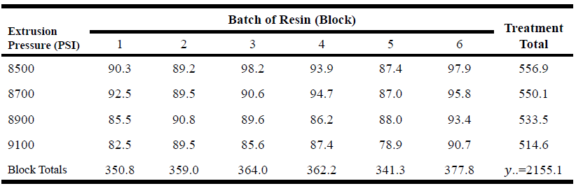

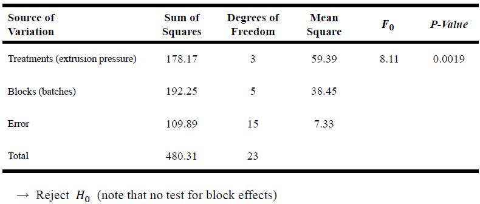

data

```r
psi = factor(c(8500, 8700, 8900, 9100))
block = factor(1:6)

dat_4_1 = expand.grid(block=block, psi=psi); dat_4_1
```

```
   block  psi
1      1 8500
2      2 8500
3      3 8500
4      4 8500
5      5 8500
6      6 8500
7      1 8700
8      2 8700
9      3 8700
10     4 8700
11     5 8700
12     6 8700
13     1 8900
14     2 8900
15     3 8900
16     4 8900
17     5 8900
18     6 8900
19     1 9100
20     2 9100
21     3 9100
22     4 9100
23     5 9100
24     6 9100
```

```r
dat_4_1$value = c(90.3, 89.2, 98.2, 93.9, 87.4, 97.9,
                  92.5, 89.5, 90.6, 94.7, 87.0, 95.8,
                  85.5, 90.8, 89.6, 86.2, 88.0, 93.4,
                  82.5, 89.5, 85.6, 87.4, 78.9, 90.7)
```

total

```r
trt_total = tapply(dat_4_1$value, dat_4_1$psi, function(x) sum(x)); trt_total
```

```
 8500  8700  8900  9100
556.9 550.1 533.5 514.6
```

```r
block_total = tapply(dat_4_1$value, dat_4_1$block, function(x) sum(x)); block_total
```

```
    1     2     3     4     5     6
350.8 359.0 364.0 362.2 341.3 377.8
```

```r
total = sum(trt_total); total # sum(block_total)
```

```
[1] 2155.1
```

RCBD design

```r
fit_RCBD = aov(value ~ psi + block, data=dat_4_1) # block이 추가
anova(fit_RCBD) # (trt)H0를 기각한다, block의 검정값은 관심사가 아니다
```

```
Analysis of Variance Table

Response: value
          Df Sum Sq Mean Sq F value   Pr(>F)
psi        3 178.17  59.390  8.1071 0.001916 **
block      5 192.25  38.450  5.2487 0.005532 **
Residuals 15 109.89   7.326
---
Signif. codes:  0 '***' 0.001 '**' 0.01 '*' 0.05 '.' 0.1 ' ' 1
```

모형의 타당성 검정

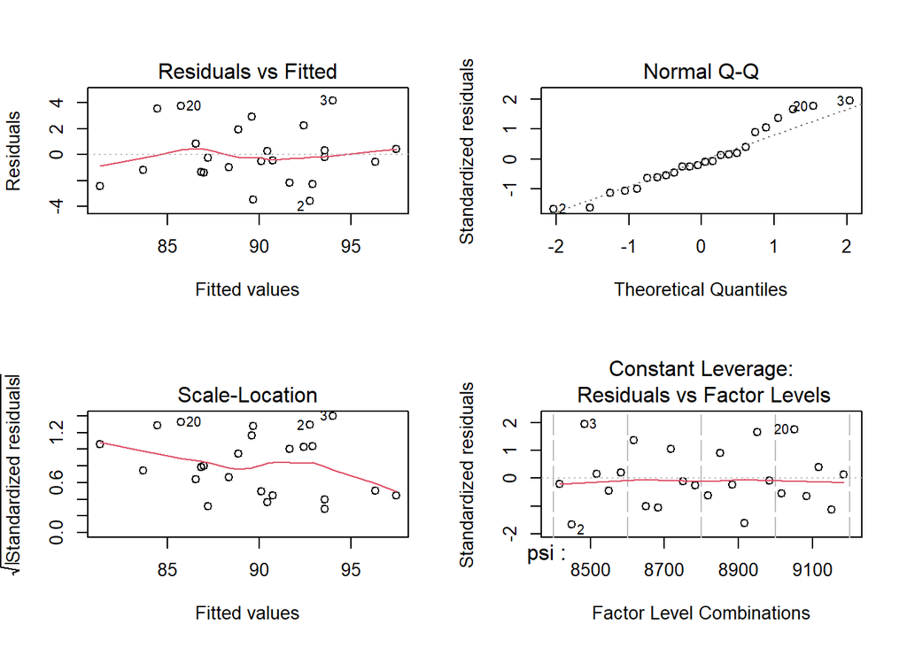

```r
# Model Adequacy checking (Normality, constant variance, independence)
par(mfrow=c(2,2))
plot(fit_RCBD)
```

```r
shapiro.test(fit_RCBD$residuals)
```

```
    Shapiro-Wilk normality test

data:  fit_RCBD$residuals
W = 0.95631, p-value = 0.3689
```

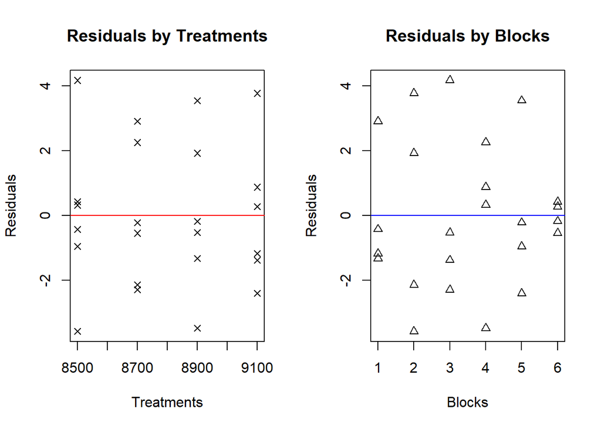

```r
# Some other plots
Resid = fit_RCBD$residuals ## resid(fit_RCBD)

par(mfrow=c(1,2))

plot(Resid ~ as.character(dat_4_1$psi),
     xlab = 'Treatments', ylab='Residuals',
     main = 'Residuals by Treatments', pch = 4) # as.character로 변경 안하면 box plot이 결과물로 나옴
abline(h=0, col='red')

plot(Resid ~ as.character(dat_4_1$block),
     xlab = 'Blocks', ylab='Residuals',
     main = 'Residuals by Blocks', pch = 2)
abline(h=0, col='blue')
```

### Some Other Aspects of RCBD(같은 데이터를 CRD로 분석)

- ANOVA table(run by CRD, n=b=6)

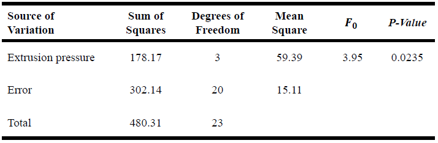

- 둘다 H0를 기각 하지만 RCBD가 더 민감하게 검정(F0값이 더 크다)
- CRD의 $SS_E, \ df_E$는 RCBD에선 partitioning돼서 $SS_E+SS_B, \ df_E+df_B$값과 같다

  (F0값이 변한 이유)

CRD와 RCBD비교

```r
# CRD
fit_CRD = aov(value ~ psi, data=dat_4_1)
anova(fit_CRD)
```

```
Analysis of Variance Table

Response: value
          Df Sum Sq Mean Sq F value  Pr(>F)
psi        3 178.17  59.390  3.9313 0.02345 *
Residuals 20 302.14  15.107
---
Signif. codes:  0 '***' 0.001 '**' 0.01 '*' 0.05 '.' 0.1 ' ' 1
```

```r
# RCBD
fit_RCBD = aov(value ~ psi + block, data=dat_4_1)
anova(fit_RCBD)
```

```
Analysis of Variance Table

Response: value
          Df Sum Sq Mean Sq F value   Pr(>F)
psi        3 178.17  59.390  8.1071 0.001916 **
block      5 192.25  38.450  5.2487 0.005532 **
Residuals 15 109.89   7.326
---
Signif. codes:  0 '***' 0.001 '**' 0.01 '*' 0.05 '.' 0.1 ' ' 1
```

### Random Treatments and/or Blocks

- model: $y_{ij} = \mu + \tau_i + \beta_j + \epsilon_{ij}; \ where \ \tau_j \ is \ fixed \ and \ \beta_j \ is \ random(\beta_j\sim IN(0,\sigma^2_\beta))$
- 통계량: $F_0 = \frac{MS{Treatment}}{MS_E}$
- ANOVA-type Estimator of $\tau^2_\beta$:

  $$\widehat{\sigma}^2_\beta = \frac{(MS_{Block} - MS_E)}{a}\\\rightarrow E(MS_{Block})=\sigma^2+a\sigma^2_\beta$$

lme4 패키지를 이용해 분석

```r
# Blocks are assumed random
library(lme4)

fit_rblock = lmer(value ~ psi + (1|block), data = dat_4_1); fit_rblock
```

```
Linear mixed model fit by REML ['lmerMod']
Formula: value ~ psi + (1 | block)
   Data: dat_4_1
REML criterion at convergence: 112.0424
Random effects:
 Groups   Name        Std.Dev.
 block    (Intercept) 2.789
 Residual             2.707
Number of obs: 24, groups:  block, 6
Fixed Effects:
(Intercept)      psi8700      psi8900      psi9100
     92.817       -1.133       -3.900       -7.050
```

```r
# draw variance component
vc = as.data.frame(VarCorr(fit_rblock)); vc
```

```
       grp        var1 var2     vcov    sdcor
1    block (Intercept) <NA> 7.781167 2.789474
2 Residual        <NA> <NA> 7.325750 2.706612
```

```r
var_block = vc[1,4]; var_block
```

```
[1] 7.781167
```

```r
var_resid = vc[2,4]; var_resid
```

```
[1] 7.32575
```

### Estimating Missing Values

Estimating the missing observation 𝑥so that it will have a minimum contribution to the

error sum of squares

- $\frac{\partial }{\partial x}(SS_E)=0$을 만족 시키는 x 값 공식: ($y\cdot$은 해당 결측치 x에 해당하는 위치 i, j의 y값)

  $$x=\frac{ay_{i.}\cdot+by_{.j}\cdot-y_{..}\cdot}{(a-1)(b-1)}$$
- $df_E$는 결측치 갯수 만큼 빼고 $df_T$는 그대로이다($df_E$-1)
- example

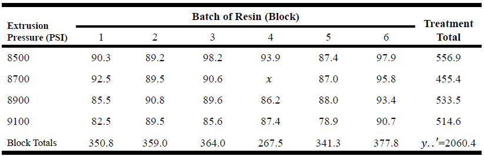

- example 결측값:

data

```r
# Estimating Missing values
psi = factor(c(8500,8700,8900,9100))
block = factor(1:6)

dat_4_1 = expand.grid(block=block, psi=psi); dat_4_1
```

```
   block  psi
1      1 8500
2      2 8500
3      3 8500
4      4 8500
5      5 8500
6      6 8500
7      1 8700
8      2 8700
9      3 8700
10     4 8700
11     5 8700
12     6 8700
13     1 8900
14     2 8900
15     3 8900
16     4 8900
17     5 8900
18     6 8900
19     1 9100
20     2 9100
21     3 9100
22     4 9100
23     5 9100
24     6 9100
```

```r
dat_4_1$value = c(90.3, 89.2, 98.2, 93.9, 87.4, 97.9,
                  92.5, 89.5, 90.6, 94.7, 87.0, 95.8,
                  85.5, 90.8, 89.6, 86.2, 88.0, 93.4,
                  82.5, 89.5, 85.6, 87.4, 78.9, 90.7)


dat_4_1$value[10] = NA; dat_4_1 # 10번째 값이 결측치
```

```
   block  psi value
1      1 8500  90.3
2      2 8500  89.2
3      3 8500  98.2
4      4 8500  93.9
5      5 8500  87.4
6      6 8500  97.9
7      1 8700  92.5
8      2 8700  89.5
9      3 8700  90.6
10     4 8700    NA
11     5 8700  87.0
12     6 8700  95.8
13     1 8900  85.5
14     2 8900  90.8
15     3 8900  89.6
16     4 8900  86.2
17     5 8900  88.0
18     6 8900  93.4
19     1 9100  82.5
20     2 9100  89.5
21     3 9100  85.6
22     4 9100  87.4
23     5 9100  78.9
24     6 9100  90.7
```

```r
mis_lev = dat_4_1[is.na(dat_4_1$value),]; mis_lev
```

```
   block  psi value
10     4 8700    NA
```

결측치 예측

yi._prime = sum(dat_4_1[dat_4_1$psi == mis_lev[,‘psi’], ‘value’], na.rm = T); yi._prime

- dat_4_1[dat_4_1$psi == mis_lev[,‘psi’], ‘value’]: mis_lev에서 열psi(8700)가 같은 value를 가져옴
- sum(,na.rm = T): NA값이 있으면 제거하고 합함(오류가 나지 않음)

```r
a = length(levels(dat_4_1$psi)); a # trt의 갯수
```

```
[1] 4
```

```r
b = length(levels(dat_4_1$block)); b # block의 갯수
```

```
[1] 6
```

```r
yi._prime = sum(dat_4_1[dat_4_1$psi == mis_lev[,'psi'], 'value'], na.rm = T); yi._prime # 결측치와 같은 위치trt인 값 합
```

```
[1] 455.4
```

```r
y.j_prime = sum(dat_4_1[dat_4_1$block == mis_lev[,'block'], 'value'], na.rm = T); y.j_prime # 결측치와 같은 위치block인 값 합
```

```
[1] 267.5
```

```r
y.._prime = sum(dat_4_1$value, na.rm = T); y.._prime # 결측치를 제외한 전체 합
```

```
[1] 2060.4
```

```r
x = (a*yi._prime + b*y.j_prime - y.._prime) / ((a-1)*(b-1)); x
```

```
[1] 91.08
```

결측치 있는 모델 분석(결측치를 고려 안함)

```r
impute_dat = dat_4_1 # dat_4_1복사
impute_dat[is.na(dat_4_1$value),'value'] <- x

fit_impute = aov(value ~ psi + block, data = impute_dat); fit_impute # (결측치를 고려 안함)
```

```
Call:
   aov(formula = value ~ psi + block, data = impute_dat)

Terms:
                     psi    block Residuals
Sum of Squares  166.1438 189.5220  101.6960
Deg. of Freedom        3        5        15

Residual standard error: 2.603792
Estimated effects may be unbalanced
```

결측치 있는 모델 분석(결측치를 고려)

```r
res_impute = anova(fit_impute); res_impute
```

```
Analysis of Variance Table

Response: value
          Df Sum Sq Mean Sq F value   Pr(>F)
psi        3 166.14  55.381  8.1686 0.001852 **
block      5 189.52  37.904  5.5908 0.004193 **
Residuals 15 101.70   6.780
---
Signif. codes:  0 '***' 0.001 '**' 0.01 '*' 0.05 '.' 0.1 ' ' 1
```

```r
# 결측치를 고려한 anova 계산
ss_vec = res_impute$'Sum Sq'; ss_vec
```

```
[1] 166.1438 189.5220 101.6960
```

```r
df_vec = res_impute$Df; df_vec
```

```
[1]  3  5 15
```

```r
ms_trt = ss_vec[1]/df_vec[1]; ms_trt
```

```
[1] 55.38127
```

```r
ms_r = ss_vec[3]/(df_vec[3] - 1); ms_r
```

```
[1] 7.264
```

```r
f_value = ms_trt/ms_r; f_value
```

```
[1] 7.624073
```

```r
pf(f_value, 3, 14, lower.tail=F)
```

```
[1] 0.002919634
```

```r
1- pf(f_value, 3, 14)
```

```
[1] 0.002919634
```

결측치 있는 모델 분석 함수(결측치를 고려)

```r
# customizing impute method
# consider n treatments and k missing values
impute_missing = function(value, trt)
{
  # value = dat_4_1$value
  # trt = dat_4_1[,1:2]

  n = ncol(trt)
  mis_idx = which(is.na(value))

  coef_trt = rep(0,n)
  for(k in 1:n)
  {
    coef_trt[k] = length(levels(trt[,k]))
  }

  trt_sum = list()
  for(i in 1:n)
  {
    trt_sum[[i]] = tapply(value, trt[,i], function(x) sum(x,na.rm=T))
  }
  total_sum = sum(trt_sum[[1]])

  tmp_sum = rep(0,n)
  for(j in 1:length(mis_idx))
  {
    for(i in 1:n)
    {
      tmp_idx = which(trt[mis_idx,i]==levels(trt[,i]))
      tmp_sum[i] = trt_sum[[i]][tmp_idx]
    }
    value[mis_idx[j]] = (sum(tmp_sum*coef_trt) - total_sum) / prod((coef_trt-1))
  }

  data = data.frame(trt,value)
  return(data)
}

impute_dat = impute_missing(dat_4_1$value, dat_4_1[,1:2]); impute_dat
```

```
   block  psi value
1      1 8500 90.30
2      2 8500 89.20
3      3 8500 98.20
4      4 8500 93.90
5      5 8500 87.40
6      6 8500 97.90
7      1 8700 92.50
8      2 8700 89.50
9      3 8700 90.60
10     4 8700 91.08
11     5 8700 87.00
12     6 8700 95.80
13     1 8900 85.50
14     2 8900 90.80
15     3 8900 89.60
16     4 8900 86.20
17     5 8900 88.00
18     6 8900 93.40
19     1 9100 82.50
20     2 9100 89.50
21     3 9100 85.60
22     4 9100 87.40
23     5 9100 78.90
24     6 9100 90.70
```

## Balanced Incomplete Block Design (BIBD)

# Chapter 5 Factorial Experiments

## Basic Definitions and Principles

### Some Basic Definitions

Factorial Designs: Most efficient in studying the effects of two or more factors

Definition of a factor (main) effect: The change in the mean response when the factor is changed from low to high

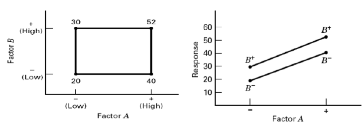

## Two Factor Factorial Design

### Example 5.1: The Battery Life Experiment

### The General Two Factor Factorial Experiment

### Analysis of Variance Table

### The Battery Design Experiment

### The Assumption of No Interaction

## The General Factorial Design

### Three Factor Factorial Design

### Factorials with more than two factors

### Example 5.3: The Soft Drink Bottling Problem